# Project "Boston housing"

### Testing *rm*

```python
data_medv_low.rm.describe()
```

```
count    437.000000
mean       6.112847
std        0.536631
min        3.561000
25%        5.857000
50%        6.127000
75%        6.431000
max        8.780000
Name: rm, dtype: float64
```

```python
data_medv_high.rm.describe()
```

```
count    69.000000
mean      7.372623
std       0.655013
min       4.970000
25%       6.998000
50%       7.267000
75%       7.820000
max       8.725000
Name: rm, dtype: float64
```

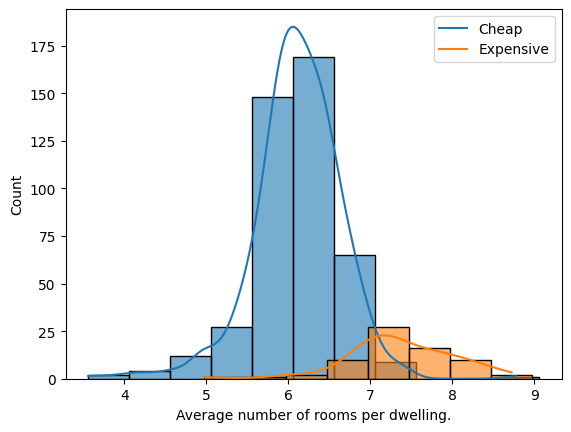

```python
b1 = sns.histplot(data_medv_low.rm, kde=True,
                  alpha=0.6, binwidth=0.5);
b2 = sns.histplot(data_medv_high.rm, kde=True,
                  alpha=0.6, binwidth=0.5);
plt.legend(['Cheap', 'Expensive']);
plt.xlabel('Average number of rooms per dwelling.');
```

```python
pval_mann_rm = mannwhitneyu(data_medv_low.dis, data_medv_high.rm, alternative='less').pvalue
print('Expensive suburbs have greater average number of rooms per dwelling than cheap ones',
      f'with one sided Mann-Whitney U test p-value: {pval_mann_rm}')
```

[output not shown]

### Testing *ptratio*

```python
data_medv_low.ptratio.describe()
```

```
count    437.000000
mean      18.778490
std        1.976883
min       12.600000
25%       17.800000
50%       19.200000
75%       20.200000
max       22.000000
Name: ptratio, dtype: float64
```

```python
data_medv_high.ptratio.describe()
```

```
count    69.000000
mean     16.410145
std       2.198806
min      12.600000
25%      14.700000
50%      17.400000
75%      17.900000
max      20.200000
Name: ptratio, dtype: float64
```

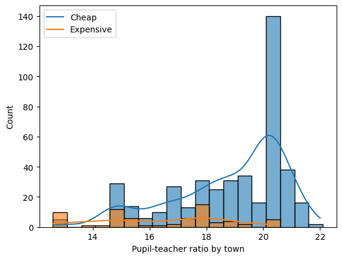

```python
sns.histplot(data_medv_low.ptratio, kde=True, alpha=0.6, binwidth=0.5);
sns.histplot(data_medv_high.ptratio, kde=True, alpha=0.6, binwidth=0.5);
plt.legend(['Cheap', 'Expensive']);
plt.xlabel('Pupil-teacher ratio by town');
# plt.ylim(0, 60);
```

```python
pval_mann_ptratio = mannwhitneyu(data_medv_low.ptratio, data_medv_high.ptratio, alternative='greater').pvalue
print('Expensive suburbs have less Pupil-teacher ratio by town than cheap ones',
      f'with one sided Mann-Whitney U test p-value: {pval_mann_ptratio}')
```

```
Expensive suburbs have less Pupil-teacher ratio by town than cheap ones with one sided Mann-Whitney U test p-value: 1.9715109522953002e-15
```

**After testing three most significant predictors I can say that higher cost of suburbs significantly depends on**

1. lower status of population
2. number of rooms
3. pupil-teacher ratio

The first parameter is interesting because the population with "low status" simply cannot buy expensive houses. So the correlation is high.  
The second parameter is clear - big house = big price.  
The third is the dependence on education. The small number of students in one class is characteristic of private schools, which usually educate the children of wealthy parents.

### Testing *nox*

```python
data_medv_low.nox.describe()
```

```
count    437.000000
mean       0.564281
std        0.117315
min        0.385000
25%        0.464000
50%        0.538000
75%        0.647000
max        0.871000
Name: nox, dtype: float64
```

```python
data_medv_high.nox.describe()
```

```
count    69.000000
mean      0.493984
std       0.084527
min       0.394000
25%       0.437000
50%       0.458000
75%       0.575000
max       0.668000
Name: nox, dtype: float64
```

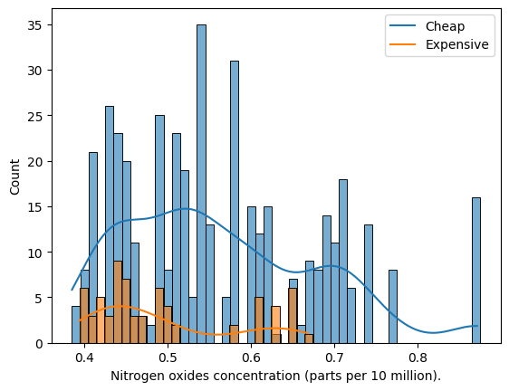

```python
b1 = sns.histplot(data_medv_low.nox, kde=True,
                  alpha=0.6, binwidth=0.01);
b2 = sns.histplot(data_medv_high.nox, kde=True,
                  alpha=0.6, binwidth=0.01);
plt.legend(['Cheap', 'Expensive']);
plt.xlabel('Nitrogen oxides concentration (parts per 10 million).');
# plt.ylim(0,15);
```

```python
pval_mann_nox = mannwhitneyu(data_medv_low.nox, data_medv_high.nox, alternative='greater').pvalue
print('Expensive suburbs have less Nitrogen oxides concentration (parts per 10 million) than cheap ones',
      f'with one sided Mann-Whitney U test p-value: {pval_mann_nox}')
```

```
Expensive suburbs have less Nitrogen oxides concentration (parts per 10 million) than cheap ones with one sided Mann-Whitney U test p-value: 3.640067266843077e-07
```

**The same shape of distribution, but different mean value**  
Looks like it is two groups among all suburbs: with high nitrogen oxides concentration and lowe (two maximum peaks on the distribution)

### Testing *crim*

```python
data_medv_low.crim.describe()
```

```
count    437.000000
mean       4.063478
std        9.147717
min        0.006320
25%        0.092990
50%        0.290900
75%        4.541920
max       88.976200
Name: crim, dtype: float64
```

```python
data_medv_high.crim.describe()
```

```
count    69.000000
mean      0.763810
std       1.837559
min       0.009060
25%       0.037680
50%       0.086640
75%       0.534120
max       9.232300
Name: crim, dtype: float64
```

```
(0.0, 150.0)
```

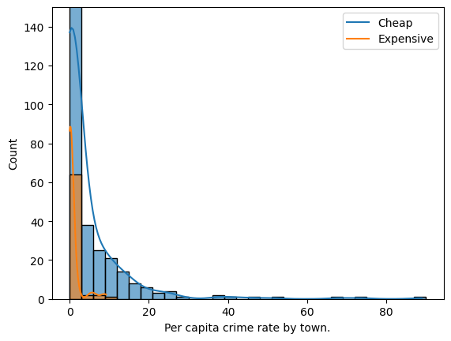

```python
b1 = sns.histplot(data_medv_low.crim, kde=True,
                  alpha=0.6, binwidth=3);
b2 = sns.histplot(data_medv_high.crim, kde=True,
                  alpha=0.6, binwidth=3);
plt.legend(['Cheap', 'Expensive']);
plt.xlabel('Per capita crime rate by town.');
plt.ylim(0, 150)
```

```python
pval_mann_crim = mannwhitneyu(data_medv_low.crim, data_medv_high.crim, alternative='greater').pvalue
print('Expensive suburbs have less per capita crime rate by town than cheap ones',
      f'with one sided Mann-Whitney U test p-value: {pval_mann_crim}')
```

```
Expensive suburbs have less per capita crime rate by town than cheap ones with one sided Mann-Whitney U test p-value: 6.192291924409378e-07
```

**Cheap districs in some occausions have very high criminality rate (up to 89). Expensive ones have maximum 9 *crim***

### Testing *zn*

```python
data_medv_low.zn.describe()
```

```
count    437.000000
mean       8.599542
std       20.099033
min        0.000000
25%        0.000000
50%        0.000000
75%        0.000000
max      100.000000
Name: zn, dtype: float64
```

```python
data_medv_high.zn.describe()
```

```
count    69.000000
mean     28.869565
std      33.004529
min       0.000000
25%       0.000000
50%      20.000000
75%      45.000000
max      95.000000
Name: zn, dtype: float64
```

```
(0.0, 60.0)
```

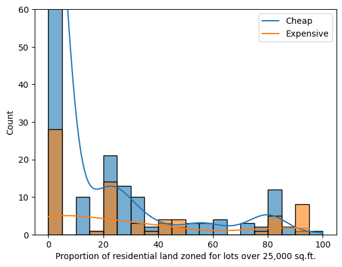

```python
b1 = sns.histplot(data_medv_low.zn, kde=True,
                  alpha=0.6, binwidth=5);
b2 = sns.histplot(data_medv_high.zn, kde=True,
                  alpha=0.6, binwidth=5);
plt.legend(['Cheap', 'Expensive']);
plt.xlabel('Proportion of residential land zoned for lots over 25,000 sq.ft.');
plt.ylim(0, 60)
```

```python
pval_mann_zn = mannwhitneyu(data_medv_low.zn, data_medv_high.zn, alternative='less').pvalue
print('Expensive suburbs have greater proportion of residential land zoned for lots over 25,000 sq.ft. than cheap ones',
      f'with one sided Mann-Whitney U test p-value: {pval_mann_zn}')
```

```
Expensive suburbs have greater proportion of residential land zoned for lots over 25,000 sq.ft. than cheap ones with one sided Mann-Whitney U test p-value: 3.8556018089623235e-12
```

#### Scatter

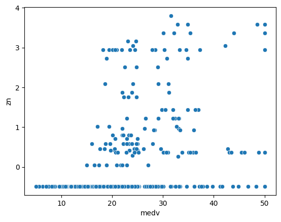

```python
sns.scatterplot(x=medv, y=scaled_preds.zn);
```

**But there are a lot of zero values**  
Yes expensive houses have less zero *zn*, but it looks like there are simply less expensive houses.  
However correlation exists: a lot of such zones => less houses in suburbs and more lands per house => higher cost